# Final Assignment - CSC8631

Chatwipa Surapat

2024-11-13

# 1. First investigation

## 1.1 Business Understanding

Online learning is one of the popular learning methods today due to its accessibility and flexibility. However, it has both pros and cons. Since courses are easy to access, many students give up studying and decide to un-enroll after a few days, while some un-enroll immediately after starting the first section. Therefore, this report focuses on understanding the reasons for un-enrollment and how to improve the course to avoid student dropouts.

### 1.1.1 Business objectives and success criteria

The objective of this report is to analyse the factors contributing to student withdrawal in order to gain insights to understand the issues and identify strategies for improving the course. The analysis should cover the reasons for student withdrawal, the progression of course improvements over time, and potential enhancements for future course.

### 1.1.2 Requirements, assumptions, and constrains

The data set in this analysis come from the “Cyber Security: Safety At Home, Online, and in Life” course made by `Newcastle University` which public and collect the data through `FutureLearn`, virtual learning provider.

The `R Project Template` is used to structure and organize the analysis, in combination with `renv` to manage R libraries, ensuring that the results are reproducible. Additionally, `Git` is used to back up the project and track changes throughout the development period.

The students withdrawal survey is expected to identify the issues of course and address the course improvement method. However, some survey responses may be incomplete, as some question in the survey is compulsory. Consequently, the analysis results may not represent the entire student population.

### 1.1.3 Risk and contingencies

As mentioned, student survey is the primary source that used for analysis, which relies on user-provided input but it might contain missing response in some question that might effect to the analysis result. Therefore, the data set will be cleaned and selected the relevant responses for analysis, depending on the specific business question being addressed.

## 1.2 Data Understanding

### 1.2.2 Data exploration

The course structure was provided in *.pdf* format. There are three sections in this course, including exploring personal privacy online, online payment security, and future home security. However, there have been some changes to the course structure across runs, which might be one of the factors affecting un-enrollment.

Enrollment summary

| Run No. | Enrollments | Full Participate | %Full Participate | Un-enrollment | %Un-enrollment |
| --- | --- | --- | --- | --- | --- |
| 1 | 14394 | 1803 | 12.53 | 1212 | 8.42 |
| 2 | 6488 | 33 | 0.51 | 1200 | 18.50 |
| 3 | 3361 | 56 | 1.67 | 500 | 14.88 |
| 4 | 3992 | 166 | 4.16 | 560 | 14.03 |
| 5 | 3544 | 22 | 0.62 | 407 | 11.48 |
| 6 | 3175 | 31 | 0.98 | 203 | 6.39 |
| 7 | 2342 | 43 | 1.84 | 109 | 4.65 |

Furthermore, the number of student surveys also changed overtime and some pf the reponse files are empty. The details of empty files of each runs are provided in the table below, where “x” indicates an empty file and “o” indicates a present file.

Summary of different survey files

| No.Run | Archetype | Enrollment | Leave | Quiz | Activity | Team | Video | Sentiment |
| --- | --- | --- | --- | --- | --- | --- | --- | --- |
| 1 | x | o | x | o | o | x | x | x |
| 2 | x | o | x | o | o | o | x | x |
| 3 | o | o | x | o | o | o | o | x |
| 4 | o | o | o | o | o | o | o | x |
| 5 | o | o | o | o | o | o | o | o |
| 6 | o | o | o | o | o | o | o | o |
| 7 | o | o | o | o | o | o | o | o |

From this summary table, quantitative data on un-enrollment can be observed across different runs. However, it is important to note that there are no leaving survey response in the first three runs, which limits insights into student withdrawal reasons for those runs.

Two survey responses, including *cyber.security.n_leaving.survey.responses* and *cyber.security.n_enrolments*, are used as the primary files for the un-enrollment analysis, where “n” represents the run number. The leaving survey includes the information about reason of un-enrollment, withdrawal dates and learning hours are the primary information that used for the analysis. The enrollments survey primarily focuses on student demographics, enrollment dates, and withdrawal dates.

There is a link between these two data frames. The *learner_id* variable is present in both files and can be used to join them. Additionally, both data frames contain a variable for the time stamp of un-enrollment, but they use different column names. For better clarity, the descriptions of each column used in this analysis are summarized in the table below.

Description of used survey columns

| Column | Description | Survey |
| --- | --- | --- |
| learner_id | Unique identifier for each student | Leave, Enrollment |
| enrolled_at | Time stamp of enrollment | Enrollment |
| unenrolled_at | Time stamp of un-enrollment (same as `left_at`) | Enrollment |
| left_at | Time stamp of un-enrollment (same as `unenrolled_at`) | Leave |
| employment_status | Current employment status of the student | Enrollment |
| leaving_reason | Reason of leaving the course | Leave |

## 1.3 Data preparation

The pre-processing script is stored in the `munge` folder of the project template. This file will be processed automatically upon starting the project for the first time. The pre-processed file will then be stored in the `cache` folder to reduce processing time for subsequent runs. In this investigation, `01-Combined_leave` serves as the primary file for pre-processing the data. Only *cyber.security.n_leaving.survey.responses* and *cyber.security.n_enrolments* are selected to analyze factors related to learner un-enrollment.

First, all columns related to time in both response files were processed to convert the data type to POSIX time, and any apostrophes were standardized to avoid errors caused by inconsistent symbols. Then, rows from each type of survey response were combined to generate two data frames including all leaving surveys and enrollment surveys, with the adding of running number column for separation. In total, the leaving survey contains 403 observations with 9 variables across all runs, while the enrollment survey contains 37,296 observations with 14 variables. Finally, both data frames were joined by `full_join()` function that matching the *learner_id* column to create the `preprocessed_leave` data frame for analysis. This method will keep all observations in both data frame and add the `NA` value in the empty field.

The pre-processed data frame contains 37,304 observations across 21 variables, which is higher than the total rows in *cyber.security.n_enrolments*, which contains 37,296 rows. This discrepancy is due to some learners providing multiple responses to questions, resulting in multiple entries for the same learner ID in the leaving survey.

### 1.4 Modeling

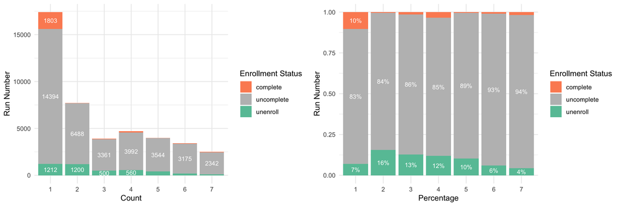

Percentage of enrollment status

Upon reviewing the course overview, the second run of this course introduced additional steps to the course structure: 1 step in the first section and 2 steps in the second section. However, the third run removed one step from the final session. These change may have influenced the student withdrawal rate.

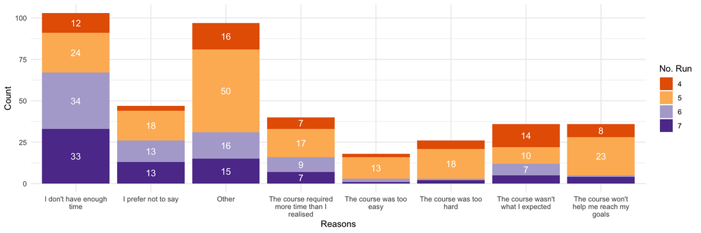

Distribution of leaving reasons

The chart shows that time management is the primary problem making learner decided to withdraw the course, observing from high counts of I don’t have enough time” and “The course required more time than I realized” categories. There are low number of student that withdraw the course due to skill alignment, course difficulty and course expectations, indicating the the difficulty level of this course might be generally acceptable for most of students. In addition, there are high number of students that withdraw the course from other reasons.

These data suggest that the number of steps in the course is an important factor influencing the withdrawal rate. Since many students encounter time management problems, increasing the number of steps in the course may contribute to higher withdrawal rate. However, since the course structure has remained unchanged after the third run and the percentage of student withdrawal consistently decrease, suggesting that the structure of this course may now be suitable for the average learner.

This report proposes three potential solutions to enhance course performance. First, providing a study plan may help students see the time required for this course and the timeline for completion more clearly. For example, students could be given an estimate of study hours per week, and the platform could then generate a personalized study plan based on this information. This would enhance students’ ability to manage their time and reduce withdrawal rate. Second, introducing a pre-test exam before enrollment could help students understand the overall content provided in this course. If a student scores high on the pre-test, it may suggest that the course is too easy for them. In contrast, if a student cannot answer all the questions provided, it may suggest that the course is too challenging for them at this time, and they may need to study some background knowledge before enrolling. Lastly, providing a expected learning outcomes to student before enrollment is one of the possible solutions. The summary of learning outcome would help student access whether the course aligns with their expectations.

## 1.5 Evaluation

In this investigation, the analysis shows that time management is the most common reason for un-enrollment. However, skill alignment and course expectations are also challenges that should be addressed to improve future course performance. The data shows that the withdrawal rate consistently decreases after the course structure adjustment in the third run, indicating that the current course structure is suitable for most learners. Additionally, three possible solutions have been suggested based on the data findings to enhance course performance. Therefore, this report achieve the success criteria because it can answer all questions in the section 1.1.1.

However, the most important factor of un-enrollment rate that could not identify in this investigation is the quality of the course. Thus, the survey responses of experience rating provided by learner should be used to evaluate the course quality and find the possible improvement in the next investigation round.

# 2. Second investigation

## 2.1 Business Understanding

The quality of the course is one of the key factors affecting un-enrollment. Although the data shows a decreasing trend in student withdrawals, the number of enrollments has also declined. Therefore, evaluating course quality is essential to ensure that the current course structure and teaching methods are suitable for the majority of students.

### 2.1.1 Business Objectives and Success Criteria

The objective of this report is to assess course quality by analyzing student satisfaction and experience ratings. The analysis will cover overall experience ratings and satisfaction trends. Additionally, sentiment analysis will be used to identify areas for improvement by examining both positive and negative feedback.

### 2.1.2 Requirements, Assumptions, and Constraints

All requirements and constraints from the first investigation (Section 1.1.2) continue to apply. This investigation assumes that student experience ratings and sentiment analysis can effectively address course quality and provide insights for further improvement.

### 2.1.3 Risks and Contingencies

Since sentiment responses were collected only from the last three runs, the findings may not fully represent student sentiments across all runs. Additionally, the accuracy of sentiment analysis depends on data quality. Ambiguous language in the data can impact interpretation, so reviewing the actual feedback sentences is necessary to ensure that the sentiment analysis interpretations are reasonable.

## 2.2 Data Understanding

### 2.2.1 Initial data collection

There are seven sentiment survey response files provided in this data set. However, the files from first to fourth run are empty. So, only the files from the fifth, sixth, and seventh runs are available for analysis.

### 2.2.2 Data exploration

*cyber.security.n_weekly.sentiment.survey.responses* is the primary file for this analysis, where “n” represents the run number. For better understanding, the description of each column that used in this analysis are summarized in the table below.

Description of column in sentiment survey

| Column | Description |
| --- | --- |
| id | Unique identifier for each student |
| responded_at | The timestamp when the survey response was submitted. |
| week_number | Week of the course during which the survey was taken |
| experience_rating | A numeric rating given by the student |
| reason | Feedback provided by the student |

As mentioned, although this data set has 7 runs, there are only fifth, sixth and seventh run that have the sentiment responses. The detail of sentiment survey responses are provided in the table below.

Sentiment survey summary

| Run No. | Total Enrollment | Full Participate | Total Responses |
| --- | --- | --- | --- |
| 1 | 14394 | 1803 | 0 |
| 2 | 6488 | 33 | 0 |
| 3 | 3361 | 56 | 0 |
| 4 | 3992 | 166 | 0 |
| 5 | 3544 | 22 | 1 |
| 6 | 3175 | 31 | 103 |
| 7 | 2342 | 43 | 77 |

In the fifth run, there is only one response from 22 learners who fully participated in the course. The table shows that the number of survey responses in the sixth and seventh runs is greater than the number of learners who completed the course. Also, there are no multiple response from the same learner tracking by the *id* column. Therefore, it might be assumed that this survey includes not only students who completed the course but also those who were currently studying.

### 2.3 Data preparation

In this investigation, `02-Combined_sentiment` serves as the primary file for pre-processing the data, which is stored in the `munge` folder and processed automatically during loading the project template. Only *cyber.security.n_weekly.sentiment.survey.responses* is selected to analyze learner satisfaction. After pre-processing, the pre-processed file will be stored in the `cache` folder.

The pre-processing process start from loading all sentiment files in the `data` folder and store into one list. After that, the script will combine all files into one data frame by row. Finally, the pre-processed data frame will be stored in `cache` folder, which reduce the computational time when reproduce the analysis. As a result, the pre-processed data frame contains 181 observations with 6 variables.

### 2.4 Modeling

The clustered bar chart below shows the distribution of experience ratings. The data indicate that most students gave a rating of 3, the highest rating, with a few giving ratings of 2 and 1, respectively. This suggests that most students are satisfied with the course.

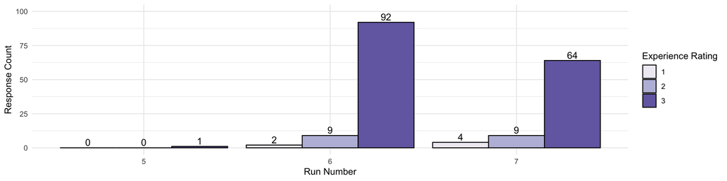

Distribution of experience rating

For the student feedback analysis, this report uses the `syuzhet` library. This library helps categorize words in each sentence into sentiments, including negative and positive words. Additionally, sentences that contain neither negative nor positive sentiments are identified as neutral. However, since there is no student feedback from the fifth run, this analysis is based solely on the sixth and seventh runs. A summary of the sentiment analysis is illustrated below.

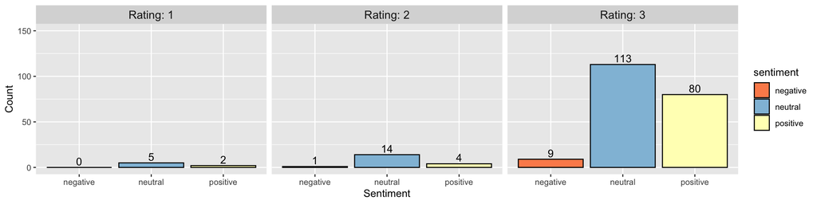

Sentiment analysis by experience rating

The clustered bar plot shows the count of each sentiment, segmented by experience rating. The data indicates that most students provided neutral feedback on the course, with positive comments increasing alongside higher rating scores. However, negative feedback also appears in experience ratings 2 and 3, which might be a potential areas for improvement. Full feedback containing negative words is shown in the table below.

Feedback contains negative words

| Number | Negative Feedback |
| --- | --- |
| 1 | I have no adverse criticisms of the course but I rushed through it |
| 2 | Thought provoking conversations and enjoyable learning at the same time. |
| 3 | The content of the course was more comprehensive than I was expecting eg. access control included. The depth of each topic covered was greater than I was expecting.A very thought provoking as well as … |
| 4 | I’ve learned a lot of things about the cyber Security in just one week!! I find out that it’s an interesting subject to learn about. |
| 5 | Only one spelling mistake… |
| 6 | I’ve had a lot of worries answered with pragmatic solutions. We tend to overcome our reservations by shear pressure to ‘do the deal’ and hope the platform is genuine and secure - not a sensible idea. |
| 7 | i like the course very much but i hated the course fees for master degree at Newcastle University as it look like discrimination against foreigner like me..how can UK citizen study master degree is 11… |

Overall, although some feedback contains negative words, positive words are also present within the same responses. The feedback highlights issues related to time management and course expectations, which align with the reasons for student withdrawal discussed in section 1.4. This finding supports that improving of these points could result in lower un-enrollment rate and increasing student stratification which indicate to course quality. Possible solutions regarding time allocation and managing expectations are presented in section 1.4. Additionally, learners appreciate that the course content is engaging and raises awareness of cyber security through thought-provoking discussions and practical solutions. However, a minor error in the course material was mentioned by student, which could be corrected and in future course runs to improve overall quality.

Referring to the clustered bar chart, there are many feedback comments containing positive words, which may not all be shown in this report. The table below highlights selected responses with more than one positive word per sentence to review the feedback from the positive sentiment group and address possible improvement of course.

Feedback contains positive words

| Number | Positive Feedback |
| --- | --- |
| 1 | It was good i have learnt new measure in protecting my money and personal data’s. Thanks |
| 2 | It has been like learning a new language. Nice reading comments. Thank you all for the course |
| 3 | Interesting accessible course |
| 4 | It has been an eye opener. The world is heading towards technology whether we like it or not! so we need to protect ourselves |
| 5 | Learning is accessible at our pace, very informative and broadening the knowledge horizon |
| 6 | The course is about blue sky thinking, very much work in progress - and plenty of plugging for Newcastle Uni. |
| 7 | Although I recently started to learn about Cybersecurity, I found the course material interesting. |
| 8 | Im paranoid about my online privacy, this week confirmed I am doing most things right and I learned a few more strategies which I can use moving forward. |
| 9 | This is my first online course and I’m very happy with the quality of the content and I’ve learned more than expected. |
| 10 | Its is a very interesting and helpful course and open our minds on what is happening on line and how to protect ourselves, our companies and family. |
| 11 | Lots of useful practical information, and theoretical concepts. Fab week. |
| 12 | Educational & Easy to access and enjoy around doing my day time job. |
| 13 | the content is comprehensible - and members appear all at a similar ability; we are holding each others’ hands so the chat is reasuring rather than the stronger pulling the weaker, so far, anyway. It … |
| 14 | Very interesting and helpful week. |
| 15 | A great insight into so many aspects - I went and did a lot of checking of my own accounts, etc. And picked up many good hints and tips on how to improve my own security. |
| 16 | a lot of external references, things to read, good ideas for improving your security! |
| 17 | I really enjoy the course And how to stay safe online |
| 18 | Got very useful information which I will use to protect myself. |
| 19 | I like the practical information on ways to improve online security. |
| 20 | I am so happy today because I can learn something valuable to me and my research for free from U.K….yeah…love from me in MALAYSIA |

There are three main points mentioned in the positive feedback group. Firstly, this course is easy for students to enroll and access the course. Furthermore, students found the information provided to be interesting and up-to-date, exceeding their expectations. Additionally, it includes many useful practical materials that learners can easily follow to improve their skills.

In order to improve the course quality, the contents’ structure of course could not be changed in the next run but the contents should be reviewed and updated to deliver interesting content to student.

## 2.5 Evaluation

The analysis results indicate that most students are satisfied with the course content, highlighting the high quality of the current course structure. Additionally, the data reveals that some of the issues contributing to student withdrawals align with negative feedback from learners, suggesting that the solutions proposed in section 1.4 could improve student satisfaction. This investigation also offers potential strategies for further enhancing course quality. Therefore, the analysis results can effectively address the business questions.

# 3. Deployment

The deliverables of this investigation consist of three items: source code, an analysis report, and a video presentation. The source code was compressed into a zip file, which contains all folders created by `ProjectTemplate`. The `README` file includes information on how to reproduce the analysis results through the source code. The analysis report is stored in the `report` folder. Additionally, the `renv` log file is also provided in the folder, which includes the library versions used in this project to ensure reproducibility. For the presentation, the presentation slides and video are compressed into a zip file. The presentation is a summary of this analysis, containing information about the methodology, data processing steps, and result interpretation.